# A3: SPL Library Checkouts

### Introduction

Due to the improvement in education levels all around the world, more and more people start borrowing books and assessing new materials from public libraries. Ernest Hemingway is one of my favorite American novelists, who strongly influenced 20th-century fiction. I started reading his novels in middle school, and I am in love with his *simple* and *fresh* writing style so much. By using the creator filter, I filtered out the data for the books which were written by *Ernest Hemingway* with checkout times and years. And By using the title filter, I filter out the data for the book *The Short Stories*, which is my favorite book written by Ernest Hemingway.

### Summary Information

- The checkout times for **The Short Stories Volume I** have an extreme increment from 2020 to 2021 (37 to 103, with an increment of 66), and the trend keeps going in 2022.
- In general, **The Short Stories Volume I** usually has more checkout times than **Volume II** and **Volume III**.
- The most checkout subject in a year for Hemingway’s book is *Classic Literature* in 2021 with 1866 times. The lowest checkout subject in a year for Hemingway’s book is **History** in 2023 and **Literary Criticism** in 2014 with 2 times.
- In general, the most checkout subject of Hemingway’s book is **Classic Literature**. The lowest checkout subjects are **Literary Criticism** and **Nonfiction**.
- Overall, Hemingway’s books have the most checkout in 2021 and 2022, and both of them are over 2000 times.
- Most people checkout Hemingway’s book with the material **Ebook** with 7680 times from 2012 to 2023, which is also 67.8% for all Hemingway’s checkout books.

### The Dataset

The data was collected and published by The Seattle Public Library. The parameters of the data are UsageClass, CheckoutType, MaterialType, CheckoutYear, CheckoutMonth, Checkouts, Title, and more with a total of 12 columns.

The data was collected by an artist and professor in The Seattle Public Library who has designed the data visualization which displays what people are checking out from the library, so the data generated by 2005 the artist had collected for the visualization work, they use that data and keep collecting it from 2017 till now.

The data was collected so that students, researchers, and more who are interested in analyzing how the checkout and years can affect society and our lives, so people can find answers like how does Black Lives Matter affect the book people checked out in the Seattle Public Library? Why is it important for us?

There are some possible limitations or problems with the library data. First, library data may be biased if it does not accurately reflect the community it serves. For example, if certain groups are underrepresented in the data, it may not provide a complete picture of library usage and needs. Second, the library data may be incomplete or inaccurate if certain data points are not collected, or if data is entered incorrectly. This data is even collected from 2017 till now but it did include the data since 2015, so the accuracy of the data is concerning. This can lead to incorrect conclusions being drawn from the data. Third, library data may contain sensitive information about library users. The collection, storage, and use of this data must be carefully managed to protect users’ privacy. There might be a part of the data that is non-public and only accessible to the people working in the Seattle library. Fourth, libraries may lack the necessary technology or resources to effectively collect, store, and analyze data. This can lead to data being lost, corrupted, or not used to its full potential. Last, even if the data is accurate and complete, its interpretation and analysis require skills and expertise that may not be readily available within the library. This can lead to incorrect conclusions being drawn from the data or missed opportunities for data-driven decision-making.

### The Short Stories Checkouts by Year since 2012

I choose to include this chart because The Short Stories series is one of my favorite series. I kept reading the book and never got sick of it, so I am interested in which book in the series will be the most popular in Seattle.

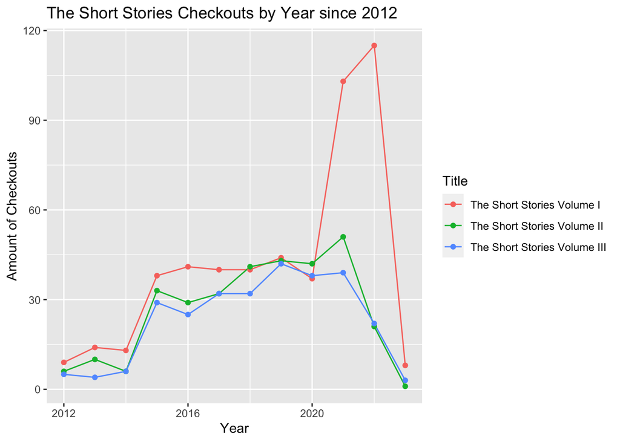

### Hemingway’s Book Checkouts Subjects by Year since 2012

I choose to include this chart because I want to know which Hemingway is because I want to explore more interesting and popular Hemingway books that I haven’t read. I calculate the checkout times by different subjects, and I can know the total checkout times after finding out every subject’s checkout time.

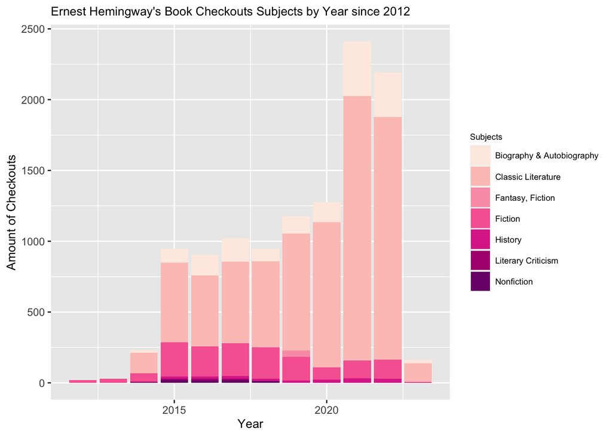

### Hemingway’s Book Checkouts Percentage by Material Type from 2012 to 2023

I choose to include this chart because I am interested in what material types are more into Hemingway’s work. For me, Ebooks definitely work way better than audiobooks, I can’t focus on the material when I have to listen to it.

Looking at the graph, 67.8% of people use the material type of ebook, 32.1% of people use audiobooks, and less than 0.1% of people use songs. This result is the same as what I expected, more people use ebooks than audiobooks.

The x and y axes aren’t presented because it is a pie charts with percentages. The independent variable (x) of the graph is the material type, and the dependent variable (y) is the total checkout percentage of each material type.

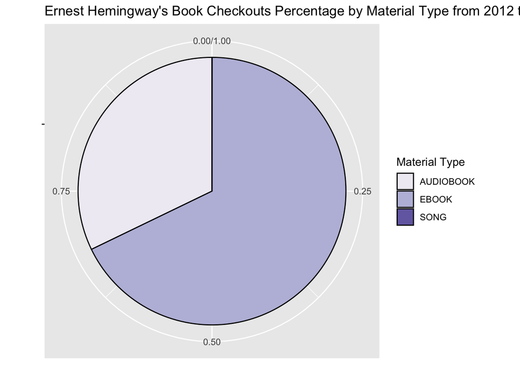